```python
from timeit import default_timer as timer
# use_cuda = torch.cuda.is_available()
# device = torch.device("cuda" if use_cuda else "cpu")
# torch.set_default_device(device)
```

# Assignment 2

In this assignment we will implement optmization techniques like Gradient Descent, Regularization, Momentum, BatchNorm, Dropout, and Learning Rate Scheduling to improve the training of the multi layer neural network. We will use the [MNIST dataset of handwritten digits](http://yann.lecun.com/exdb/mnist/) for training the classifier.  
We will use PyTorch autograd functionality to estimate the gradient for gradient descent. Write you code in between

### BEGIN SOLUTION ###

### END SOLUTION ###

```python
#import libraries and functions to load the data
from digits import get_mnist
from matplotlib import pyplot as plt
import numpy as np

import torch
from torch.autograd import grad
import torch.nn.functional as F
```

## Load and Visualize Data

MNIST dataset contains grayscale samples of handwritten digits of size 28 $\times$ 28. It is split into training set of 60,000 examples, and a test set of 10,000 examples. The legacy code below will load the data into numpy arrays and then convert them to PyTorch tensors.

```
trX.shape:  (784, 60000)
trY.shape:  (1, 60000)
tsX.shape:  (784, 10000)
tsY.shape:  (1, 10000)

Displaying a few samples
labels
[[0 9 0 5 0 7 0 0 5 6]
 [0 5 4 4 6 7 3 0 9 7]
 [8 8 8 7 6 2 2 1 9 6]
 [8 1 7 2 0 3 5 2 7 6]
 [1 0 6 3 8 0 4 1 5 5]
 [4 8 3 9 6 1 9 8 8 3]
 [7 3 9 7 8 1 3 8 4 7]
 [0 8 8 6 2 4 5 8 3 6]
 [4 7 3 5 1 3 2 7 8 9]
 [1 4 1 0 9 5 6 7 8 8]]

Corresponding images
```

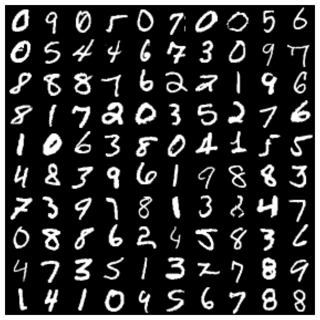

```python
# The data is of the format (no_samples, channels, img_height, img_width)
# We will reshape it to (img_height*img_width, no_samples)
# In the training data trX, there are 60000 images. Each image has one channel (gray scale).
# Each image is of height=28 and width=28 pixels
# We will use all the 60000 training examples and all the 10000 test samples.

def sample_mnist(n_train=2000, n_test=1000):
    trX, trY, tsX, tsY = get_mnist()
    #Shuffle the data.
    tr_idx = np.random.choice(trX.shape[0], n_train)
    trX = trX[tr_idx]
    trY = trY[tr_idx]
    ts_idx = np.random.choice(tsX.shape[0], n_test)
    tsX = tsX[ts_idx]
    tsY = tsY[ts_idx]
    # Reshape to [n x m]. n dimensions and m samples
    trX = trX.reshape(-1, 28*28).T
    trY = trY.reshape(1, -1)
    tsX = tsX.reshape(-1, 28*28).T
    tsY = tsY.reshape(1, -1)
    return trX, trY, tsX, tsY

# Lets verify the function
# Random seed for reproducibility
np.random.seed(1)
trX, trY, tsX, tsY = sample_mnist(n_train=60000, n_test=10000)
# Lets examine the data and see if it is normalized
print('trX.shape: ', trX.shape)
print('trY.shape: ', trY.shape)
print('tsX.shape: ', tsX.shape)
print('tsY.shape: ', tsY.shape)

# Let's visualize a few samples and their labels from the train and test datasets.
print('\nDisplaying a few samples')
visx = np.concatenate((trX[:,:50],tsX[:,:50]), axis=1).reshape(28,28,10,10).transpose(2,0,3,1).reshape(28*10,-1)
visy = np.concatenate((trY[:,:50],tsY[:,:50]), axis=1).reshape(10,-1)
print('labels')
print(visy)
print('\nCorresponding images')
plt.figure(figsize = (8,8))
plt.axis('off')
plt.imshow(visx, cmap='gray');

#convert numpy arrays to torch tensors becasue PyTorch autograd needs tensor format
trX = torch.tensor(trX, dtype=torch.float32)
trY = torch.tensor(trY, dtype=torch.int64).squeeze()
tsX = torch.tensor(tsX, dtype=torch.float32)
tsY = torch.tensor(tsY, dtype=torch.int64).squeeze()
```

```python
def relu(Z):
    '''
    Computes relu activation of input Z
    Inputs:
        Z: torch tensor (n, m) which represent 'm' samples each of 'n' dimensions
    Outputs:
        A: where A = relu(Z) is a torch tensor (n, m) representing 'm' samples each of 'n' dimensions
    '''
    # Hint: refer to torch.clamp()
    # Do not use torch.relu()
    ### BEGIN SOLUTION ###
    A = torch.clamp(Z,0)
    ### END SOLUTION ###
    return A
```

### Multi Layer Network Class (60 points)

We will define a class to model the fully connected multi layer network. The class definition will have the following parts:

1. parameters initialization (10 points)

The network parameters will be accesssed with keys "W1", "b1", "W2", "b2", etc. The dimension for weight matrix for layer $(l+1)$ is given by ( Number-of-neurons-in-layer-$(l+1)$ $\times$ Number-of-neurons-in-layer-$l$ ). The dimension of the bias for for layer $(l+1)$ is (Number-of-neurons-in-layer-$(l+1)$ $\times$ 1). We will use Kaiming-He initialization

We will also implement the following functions

2. batchnorm(...) (10 points)
3. dropout(...) (10 points)
4. forward(...) (10 points)
5. update_parameters_with_momentum(...) (20 points)

```python
class MultiLayerNetwork():
    def __init__(self, net_dims, activation_list, drop_prob_list, bnorm_list, apply_momentum=False):

        self.num_layers = len(net_dims)-1
        self.activation_list = activation_list
        self.drop_prob_list = drop_prob_list
        self.bnorm_list = bnorm_list
        self.apply_momentum = apply_momentum

        ## Intitialize parameters as a dictionary
        # self.parameters dictionary will have the following keys and values
        #    {"W1":[..],"b1":[..],"W2":[..],"b2":[..],..., \
        #        "bnorm_beta1":[..],"bnorm_gamma1":[..],"bnorm_beta2":[..],"bnorm_gamma2":[..],...}
        self.parameters = {}


        ## Initialize variables that are not parameters as a dictionary
        # self.stats dictionary will have the following keys and values
        #   {"VdW1":[..],"Vdb1":[..],"VdW2":[..],"Vdb2":[..],...} #velocity parameters for momentum
        #   {"GdW1":[..],"Gdb1":[..],"GdW2":[..],"Gdb2":[..],...} #Gradient-Squares parameters for momentum
        #   {"Vbnorm_beta1":[..],"Vbnorm_gamma1":[..],"Vbnorm_beta2":[..],\
        #         "Vbnorm_gamma2":[..],...} #batchnorm velocity parameters
        #   {"Gbnorm_beta1":[..],"Gbnorm_gamma1":[..],"Gbnorm_beta2":[..],\
        #         "Gbnorm_gamma2":[..],...} #batchnorm Gradient-Square parameters
        #   {"bnorm_running_mean1":[..],"bnorm_running_var1":[..],\
        #         "bnorm_running_mean2":[..],"bnorm_running_var2":[..],...} #batchnorm running mean and variance
        self.stats = {}


        for ly in range(self.num_layers):
            # Use Kaiming-He Initialization for weights
            # self.parameters["W"+str(ly+1)] = torch.randn(nout, nin, requires_grad=True, \
            #                                          dtype=torch.float32)*torch.sqrt(2./torch.tensor(nin))
            # self.parameters["b"+str(ly+1)] = torch.zeros((nout, 1),requires_grad=True, dtype=torch.float32)


            ### BEGIN SOLUTION ### (10 points)
            nout = net_dims[ly+1]
            nin = net_dims[ly]
            self.parameters["W"+str(ly+1)] = torch.randn(nout, nin, requires_grad=True, \
                                                     dtype=torch.float32)*torch.sqrt(2./torch.tensor(nin))
            self.parameters["b"+str(ly+1)] = torch.zeros((nout, 1),requires_grad=True, dtype=torch.float32)
            ### END SOLUTION ###

            # Batchnorm parameters and Momentum variables are initilaized below
            if apply_momentum:
                self.stats["VdW"+str(ly+1)] = torch.zeros_like(self.parameters["W"+str(ly+1)])
                self.stats["Vdb"+str(ly+1)] = torch.zeros_like(self.parameters["b"+str(ly+1)])
                self.stats["GdW"+str(ly+1)] = torch.zeros_like(self.parameters["W"+str(ly+1)])
                self.stats["Gdb"+str(ly+1)] = torch.zeros_like(self.parameters["b"+str(ly+1)])

            if bnorm_list[ly]:
                n = self.parameters["W" + str(ly+1)].shape[0]
                self.parameters['bnorm_beta'+str(ly+1)] = torch.randn(n,1,\
                                                            requires_grad=True, dtype=torch.float32)
                self.parameters['bnorm_gamma'+str(ly+1)] = torch.randn(n,1,\
                                                            requires_grad=True, dtype=torch.float32)
                self.stats['bnorm_running_mean'+str(ly+1)] = torch.zeros((n,1))
                self.stats['bnorm_running_var'+str(ly+1)] = torch.zeros((n,1))

                if apply_momentum:
                    self.stats['Vbnorm_beta'+str(ly+1)] = torch.zeros((n,1))
                    self.stats['Gbnorm_beta'+str(ly+1)] = torch.zeros((n,1))
                    self.stats['Vbnorm_gamma'+str(ly+1)] = torch.zeros((n,1))
                    self.stats['Gbnorm_gamma'+str(ly+1)] = torch.zeros((n,1))


    ## Function to implement batchnorm ## 10 Points ##
    def batchnorm(self, A, ly, mode='train'):
        '''
        Batchnorm normalizes the input x to mean beta and standard deviation gamma

        Inputs:
            A: Input after activation - shape is (n,m), m samples where each sample is (n,1)
            ly: Layer index
            mode = 'train' or 'test'

        Outputs:
            Anorm: Normalized version of input x - shape (n,m)
        '''
        # When there is no batch norm for a layer
        if self.bnorm_list[ly] == 0:
            return A

        #beta: mean vector which will be the center of the data to beta after batchnorm - shape is (n,1)
        beta = self.parameters['bnorm_beta'+str(ly+1)]
        #gamma: standard deviation vector which will be scale of the data after batchnorm - shape (n,1)
        gamma = self.parameters['bnorm_gamma'+str(ly+1)]

        # epsilon value used for scaling during normalization to avoid divide by zero.
        epsilon = 1e-5
        # Exponential Weighted Averaging for Running Batch Mean and Variance
        beta_batch_stats = 0.9

        if mode == 'train':
            ### BEGIN SOLUTION ###
            B = A.shape[0]
            mu = 1/B * torch.sum(A, 1).reshape(-1, 1)
            var = 1/B * torch.sum(torch.square(A-mu))
            # Save the batch mean 'mu' and the batch var using exponential averaging where beta is beta_batch_stats
            self.stats['bnorm_running_mean'+str(ly+1)] *= beta_batch_stats
            self.stats['bnorm_running_mean'+str(ly+1)] += (1-beta_batch_stats)*mu
            self.stats['bnorm_running_var'+str(ly+1)] *= beta_batch_stats
            self.stats['bnorm_running_var'+str(ly+1)] += (1-beta_batch_stats)*var
        else:
            # Use the running batch mean and variance during test
            mu = self.stats['bnorm_running_mean'+str(ly+1)]
            var = self.stats['bnorm_running_var'+str(ly+1)]

        A -= mu
        A /= torch.sqrt(var+epsilon)
        A *= gamma
        A += beta
        ### END SOLUTION ###
        return A

    ## Function to implement dropout ## 10 points ##
    def dropout(self, A, ly, mode='train'):
        '''
        Using the 'inverted dropout' technique to implement dropout regularization.
        Inputs:
            A: Activation input before dropout is applied - shape is (n,m)
            drop_prob: dropout parameter. If drop_prob = 0.3, we drop 30% of the neuron activations
            mode: Dropout acts differently in training and testing mode. Hence, mode is a parameter which
                takes in only 2 values, 'train' or 'test'
```

```python
        Outputs:
            A: Output of shape (n,m), with some values masked out and other values scaled to account for missing values
            cache: a tuple which stores the drop_prob, mode and mask for use in backward pass.
        '''
        # When there is no dropout return the same activation
        drop_prob = drop_prob_list[ly]
        mask = None
        if drop_prob == 0 or mode == 'test':
            return A

        # The prob_keep is the percentage of activations remaining after dropout
        # if drop_out = 0.3, then prob_keep = 0.7, i.e., 70% of the activations are retained
        prob_keep = 1-drop_prob

        # Note: instead of a binary mask implement a scaled mask, where mask is scaled by dividing it
        # by the prob_keep. For example, if we have input activations of size (3,4), then the mask is
        # mask = (torch.rand(3,4)<prob_keep)/prob_keep
        # We perform the scaling by prob_keep here so we don't have to do it specifically during backpropagation
        # We then update A by multiplying it element wise with the mask

        ### BEGIN SOLUTION ###
        mask = (torch.rand(*A.shape)<prob_keep)/prob_keep
        A *= mask
        ### END SOLUTION ###
        return A

    ## Forward propagation of input data through the network (No Softmax at the end) ## 10 Points ##
    def forward(self, x, mode='train'):
        for ly in range(self.num_layers):
            ## Apply the dot product followed by activation, batchnorm and dropout to get the logits
            ## Use torch.mm() for dot product
            ## You can use PyTorch relu or the relu() provided here
            ## Use your implementation for batchnorm and dropout
            ## Note: The last layer does not have an activation.
            ## Softmax and Cross-entropy are implemented together in the loss function F.cross_entropy()
            # But don't call F.cross_entropy here
            ### BEGIN SOLUTION ###
            x = torch.mm(self.parameters['W'+str(ly+1)], x) + self.parameters['b'+str(ly+1)]
            if ly < self.num_layers - 1:
                x = eval(self.activation_list[ly])(x)
                x = self.batchnorm(x, ly, mode)
                x = self.dropout(x, ly, mode)
            ### END SOLUTION ###
        return x

    #function to update parameters without momentum
    def update_parameters(self, gradients, alpha):
        '''
        Updates the network parameters with regular gradient descent

        Inputs:
            gradients: list of gradients for all the parameters in the network
                        The order of the list is the same as self.parameters.keys()
            alpha: The step_size for gradient descent

        Outputs:
            No outputs
        '''
        #convert gradients to a dictionary for easy access
        gradients = dict(zip(self.parameters.keys(), gradients))

        for ly in range(self.num_layers):
            # weights and bias update
            self.parameters["W"+str(ly+1)] -= alpha * gradients["W"+str(ly+1)]
            self.parameters["b"+str(ly+1)] -= alpha * gradients["b"+str(ly+1)]

            # batch norm parameters update
            if self.bnorm_list[ly]:
                self.parameters['bnorm_beta' + str(ly+1)] -= alpha * gradients["bnorm_beta"+str(ly+1)]
                self.parameters['bnorm_gamma' + str(ly+1)] -= alpha * gradients["bnorm_gamma"+str(ly+1)]


    #function to update parameters with momentum ## 20 points ##
    def update_parameters_with_momentum_Adam(self, gradients, alpha, beta=0.9, beta2=0.99, eps=1e-8):
        '''
        Updates the network parameters with Adam momentum

        Inputs:
            gradients: list of gradients for all the parameters in the network
                        The order of the list is the same as self.parameters.keys()
            alpha: The learning_rate or step_size
            beta: beta parameter for momentum (same as beta1 in Adam)
            beta2: beta2 parameter for Adam
            eps: epsilon parameter for Adam

        Outputs:
            No outputs
        Notes:
            self.parameters dictionary has the following keys and values
            {"W1":[..],"b1":[..],"W2":[..],"b2":[..],..., \
                                "bnorm_beta1":[..],"bnorm_gamma1":[..],"bnorm_beta2":[..],"bnorm_gamma2":[..],...}
            self.stats dictionary has the following keys and values

            {"VdW1":[..],"Vdb1":[..],"VdW2":[..],"Vdb2":[..],...} #velocity parameters
            {"GdW1":[..],"Gdb1":[..],"GdW2":[..],"Gdb2":[..],...} #Gradient-Squares parameters
            {"Vbnorm_beta1":[..],"Vbnorm_gamma1":[..],"Vbnorm_beta2":[..],\
                                "Vbnorm_gamma2":[..],...} #batchnorm velocity parameters
            {"Gbnorm_beta1":[..],"Gbnorm_gamma1":[..],"Gbnorm_beta2":[..],\
                                "Gbnorm_gamma2":[..],...} #batchnorm Gradient-Square parameters

            Bias correction is not required.
        '''

        gradients = dict(zip(self.parameters.keys(), gradients))

        for ly in range(self.num_layers):
            if self.apply_momentum:
                # Apply Adam momentum to parameters W's and b's.
                # You will need to update the Velocity parameters VdW's and Vdb's
                # self.stats["VdW" + str(ly+1)] =
                # self.stats["Vdb" + str(ly+1)] =
                # You will need to update the Gradient-Squares parameters GdW's and Gdb's
                # self.stats["GdW" + str(ly+1)] =
                # self.stats["Gdb" + str(ly+1)] =
                # You will need to update the parameters W's and b's
                # self.parameters["W" + str(ly+1)] =
                # self.parameters["b" + str(ly+1)] =
                # NOTE:
                # In the torch.no_grad() environment, parameter updates which are not in_place
                # may create new parameters with requires_grad=False.
                # autograd will not track gradients for the new parameters if requires_grad is False
                # Esnsure your self.parameters updates are inplace here
                # a += 1 is an inplace operation. It updates the current location of 'a'
                # a = a + 1 in NOT inplace. It creates a new location for 'a'
                ### BEGIN SOLUTION ###
                # update Velocities
                self.stats['VdW'+str(ly+1)] *= beta
                self.stats['VdW'+str(ly+1)] += (1-beta) * gradients['W'+str(ly+1)]
                self.stats['Vdb'+str(ly+1)] *= beta
                self.stats['Vdb'+str(ly+1)] += (1-beta) * gradients['b'+str(ly+1)]
                # update Gradient-Squares
                self.stats['GdW'+str(ly+1)] *= beta2
                self.stats['GdW'+str(ly+1)] += (1-beta2) * torch.square(gradients['W'+str(ly+1)])
                self.stats['Gdb'+str(ly+1)] *= beta2
                self.stats['Gdb'+str(ly+1)] += (1-beta2) * torch.square(gradients['b'+str(ly+1)])
                # update parameters
                self.parameters['W'+str(ly+1)] -= alpha / torch.sqrt(self.stats['GdW'+str(ly+1)] + eps) * self.stats['VdW'+str(ly+1)]
                self.parameters['b'+str(ly+1)] -= alpha / torch.sqrt(self.stats['Gdb'+str(ly+1)] + eps) * self.stats['Vdb'+str(ly+1)]
                ### END SOLUTION ###
            else:
                # When no momentum apply regular gradient descent
                self.parameters["W"+str(ly+1)] -= alpha * gradients["W"+str(ly+1)]
                self.parameters["b"+str(ly+1)] -= alpha * gradients["b"+str(ly+1)]
```

```python
            # The Adam momentum for batch norm parameters has been implemented below
            if self.apply_momentum and self.bnorm_list[ly]:
                # update Velocities
                self.stats['Vbnorm_beta'+str(ly+1)] = beta*self.stats['Vbnorm_beta'+str(ly+1)] + \
                                                        (1 - beta)*gradients["bnorm_beta"+str(ly+1)]
                self.stats['Vbnorm_gamma'+str(ly+1)] = beta*self.stats['Vbnorm_gamma'+str(ly+1)] + \
                                                        (1 - beta)*gradients["bnorm_gamma"+str(ly+1)]
                # update Gradient-Squares
                self.stats['Gbnorm_beta'+str(ly+1)] = beta2*self.stats['Gbnorm_beta'+str(ly+1)] + \
                                                        (1 - beta2)*(gradients["bnorm_beta"+str(ly+1)]**2)
                self.stats['Gbnorm_gamma'+str(ly+1)] = beta2*self.stats['Gbnorm_gamma'+str(ly+1)] + \
                                                        (1 - beta2)*(gradients["bnorm_gamma"+str(ly+1)]**2)
                # update parameters
                self.parameters['bnorm_beta' + str(ly+1)] -= alpha*self.stats['Vbnorm_beta'+str(ly+1)]/\
                                                            torch.sqrt(self.stats['Gbnorm_beta'+str(ly+1)] + eps)
                self.parameters['bnorm_gamma' + str(ly+1)] -= alpha*self.stats['Vbnorm_gamma'+str(ly+1)]/\
                                                            torch.sqrt(self.stats['Gbnorm_gamma'+str(ly+1)] + eps)
            elif self.bnorm_list[ly]:
                # When no momentum apply regular gradient descent
                self.parameters['bnorm_beta' + str(ly+1)] -= alpha * gradients["bnorm_beta"+str(ly+1)]
                self.parameters['bnorm_gamma' + str(ly+1)] -= alpha * gradients["bnorm_gamma"+str(ly+1)]


    ## Function to Display the Network
    def display(self):
        print('%d Layer Fully Connected Neural Network' % self.num_layers)
        for ly in range(self.num_layers):
            print('[W%s=(%dx%d),b%s=(%dx%d)'% \
                  (str(ly+1),self.parameters["W"+str(ly+1)].shape[0],\
                   self.parameters["W"+str(ly+1)].shape[1],str(ly+1),
                   self.parameters["b"+str(ly+1)].shape[0],\
                   self.parameters["b"+str(ly+1)].shape[1]), end =" ")
            if ly<self.num_layers-1:
                print('+ %s' % self.activation_list[ly], end='')
            if self.bnorm_list[ly] != 0:
                print(' + BN', end='')
            if self.drop_prob_list[ly] != 0:
                print(' + DropOut=%.1f' % self.drop_prob_list[ly], end='')
            print('] ===> ', end='')
        print('[Softmax + Cross_entropy_loss]')
```

### Training (10 points)

The `train(...)` function will implement batch gradient descent to train the model. Use PyTorch autograd to estimate gradients and update parameters during gradient descent.

```python
def train(model, x, y, num_epochs=20, learning_rate=0.1, decay_rate=1, \
          minibatch_size=32, apply_momentum=False, seed=1, log=True, log_step=500):
    cost = []

    itr = 0
    torch.manual_seed(seed)
    print(num_epochs)
    for ii in range(num_epochs):

        start = timer()
        epoch_loss = 0
        # estimate stepsize alpha using (learning_rate*1/(1+decay_rate*epoch_number))
        ### BEGIN SOLUTION ###
        alpha = (learning_rate*1/(1+decay_rate*ii))
        ### END SOLUTION ###
        if log:
            print('------- Epoch {} -------'.format(ii+1))

        ## Shuffle data in epoch and create minibatches for minibatch gradient descent
        shuffle_index = torch.randperm(y.shape[0], dtype=torch.int)
        minibatches = torch.split(shuffle_index, minibatch_size)

        for minibatch_idx in minibatches:

            ## Forward Propagation and loss ##
            ## Estimate Softmax and Cross-entropy loss using F.cross_entropy()
            ## The F.cross_entropy() function does a Softmax before the cross-entropy
            ## logits = model.forward(..., mode='train')
            ## loss = F.cross_entropy(logits.T, y[minibatch_idx])
            ### BEGIN SOLUTION ###
            logits = model.forward(x[:, minibatch_idx], mode='train')
            loss = F.cross_entropy(logits.T, y[minibatch_idx])
            ### END SOLUTION ###

            ## Compute gradient and update parameters ##
            ## The grad(.) function gets the gradients of the loss w.r.t parameters in a list
            ## The output gradients is a list of corresponding parameter gradients
            gradients = grad(loss, list(model.parameters.values()))

            with torch.no_grad():
                if apply_momentum:
                    model.update_parameters_with_momentum_Adam(gradients, alpha)
                else:
                    model.update_parameters(gradients, alpha)

            epoch_loss += loss.item()
            if log and itr % log_step == 0:
                print("Minibatch loss at iteration %i is: %.05f, learning rate: %.05f" %(itr, loss.item(), alpha))
            itr+=1


        ## Print loss every epoch ##
        epoch_loss /= len(minibatches)
        print('Epoch: %02d | Loss: %.5f | Time: %.5f | TPTI: %.5f' % ((ii+1),epoch_loss, timer()-start, (timer()-start)/itr*1000))
        cost.append(epoch_loss)
    return cost
```

### Evaluation

This function will evaluate a trained model

```python
def evaluate(model, x, y=torch.tensor([]), mode='test', minibatch_size=32):
    '''
    function to evaluate a trained model

    Inputs:
        model: trained neural network
        x: data of the form (n,m) where m is the number of samples and (n,1) is the dimension of each sample
        y: (optional) m labels in 1D tensor
        mode: (optional) 'train' or 'test'
        minibatch_size: (optional)

    Outputs:
        ypred: tensor of predicted labels in 1D tensor
        loss: model loss (>0 when labels y are provided)
        acc: percentage accuracy (>0 when labels are provided)
    '''
    shuffle_index = torch.randperm(x.shape[1], dtype=torch.int)
    minibatches = torch.split(shuffle_index, minibatch_size)
    loss = -1
    acc = -1
    if y.numel() != 0:
        ypred = -1 + torch.zeros_like(y, dtype=torch.int64)
    else:
        ypred = -1 + torch.zeros((x.shape[1]), dtype=torch.int64)
    for minibatch_idx in minibatches:
        logits = model.forward(x[:,minibatch_idx], mode)
        ypred[minibatch_idx] = torch.argmax(logits,axis = 0)
        if y.numel() != 0:
            loss += F.cross_entropy(logits.T, y[minibatch_idx])
    loss /= len(minibatches)
    if y.numel() != 0:
        acc = torch.mean((ypred == y).float())*100
    return ypred, loss, acc
```

### Train and Test (30 points)

We will intialize `model` using the `MultiLayerNetwork()` and train the model with the `train()` method We will display the training and plot the training loss. We will adjust the hyperparameters and architecture to achieve the best performance.

```
2 Layer Fully Connected Neural Network
[W1=(500x784),b1=(500x1) + relu + BN + DropOut=0.2] ===> [W2=(10x500),b2=(10x1) ] ===> [Softmax + Cross_entropy_loss]
10
------- Epoch 1 -------
Minibatch loss at iteration 0 is: 3.40667, learning rate: 0.01000
Minibatch loss at iteration 500 is: 0.68019, learning rate: 0.01000
Minibatch loss at iteration 1000 is: 0.16966, learning rate: 0.01000
Minibatch loss at iteration 1500 is: 0.42689, learning rate: 0.01000
Epoch: 01 | Loss: 0.45892 | Time: 15.68391 | TPTI: 8.36475
------- Epoch 2 -------
Minibatch loss at iteration 2000 is: 0.39408, learning rate: 0.00500
Minibatch loss at iteration 2500 is: 0.25508, learning rate: 0.00500
Minibatch loss at iteration 3000 is: 0.59696, learning rate: 0.00500
Minibatch loss at iteration 3500 is: 0.20361, learning rate: 0.00500
Epoch: 02 | Loss: 0.15856 | Time: 19.42488 | TPTI: 5.17997
------- Epoch 3 -------
Minibatch loss at iteration 4000 is: 0.20269, learning rate: 0.00333
Minibatch loss at iteration 4500 is: 0.20677, learning rate: 0.00333
Minibatch loss at iteration 5000 is: 0.02647, learning rate: 0.00333
Minibatch loss at iteration 5500 is: 0.05144, learning rate: 0.00333
Epoch: 03 | Loss: 0.11230 | Time: 19.35083 | TPTI: 3.44015
------- Epoch 4 -------
Minibatch loss at iteration 6000 is: 0.02354, learning rate: 0.00250
Minibatch loss at iteration 6500 is: 0.04383, learning rate: 0.00250
Minibatch loss at iteration 7000 is: 0.02441, learning rate: 0.00250
Epoch: 04 | Loss: 0.08764 | Time: 21.73090 | TPTI: 2.89745
------- Epoch 5 -------
Minibatch loss at iteration 7500 is: 0.18593, learning rate: 0.00200
Minibatch loss at iteration 8000 is: 0.27658, learning rate: 0.00200
Minibatch loss at iteration 8500 is: 0.02506, learning rate: 0.00200
Minibatch loss at iteration 9000 is: 0.10731, learning rate: 0.00200
Epoch: 05 | Loss: 0.07556 | Time: 24.94556 | TPTI: 2.66086
------- Epoch 6 -------
Minibatch loss at iteration 9500 is: 0.01260, learning rate: 0.00167
Minibatch loss at iteration 10000 is: 0.03435, learning rate: 0.00167
Minibatch loss at iteration 10500 is: 0.03096, learning rate: 0.00167
Minibatch loss at iteration 11000 is: 0.04242, learning rate: 0.00167
Epoch: 06 | Loss: 0.06404 | Time: 25.99488 | TPTI: 2.31066
------- Epoch 7 -------
Minibatch loss at iteration 11500 is: 0.13783, learning rate: 0.00143
Minibatch loss at iteration 12000 is: 0.06715, learning rate: 0.00143
Minibatch loss at iteration 12500 is: 0.02776, learning rate: 0.00143
Minibatch loss at iteration 13000 is: 0.01491, learning rate: 0.00143
Epoch: 07 | Loss: 0.05859 | Time: 26.34154 | TPTI: 2.00697
------- Epoch 8 -------
Minibatch loss at iteration 13500 is: 0.23173, learning rate: 0.00125
Minibatch loss at iteration 14000 is: 0.00273, learning rate: 0.00125
Minibatch loss at iteration 14500 is: 0.02024, learning rate: 0.00125
Epoch: 08 | Loss: 0.05234 | Time: 25.86016 | TPTI: 1.72401
------- Epoch 9 -------
Minibatch loss at iteration 15000 is: 0.00773, learning rate: 0.00111
Minibatch loss at iteration 15500 is: 0.01663, learning rate: 0.00111
Minibatch loss at iteration 16000 is: 0.03255, learning rate: 0.00111
Minibatch loss at iteration 16500 is: 0.01507, learning rate: 0.00111
Epoch: 09 | Loss: 0.04864 | Time: 25.18771 | TPTI: 1.49260
------- Epoch 10 -------
Minibatch loss at iteration 17000 is: 0.11802, learning rate: 0.00100
Minibatch loss at iteration 17500 is: 0.12438, learning rate: 0.00100
Minibatch loss at iteration 18000 is: 0.01376, learning rate: 0.00100
Minibatch loss at iteration 18500 is: 0.02096, learning rate: 0.00100
Epoch: 10 | Loss: 0.04344 | Time: 25.23063 | TPTI: 1.34563
Elapsed: 229.75549954400003 seconds
```

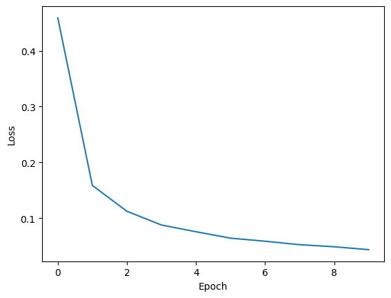

```
Accuracy for training set is 99.390 %
Accuracy for testing set is 97.400 %
```

```python
# You should be able to get a train accuracy >98% and a test accuracy >96%
# The settings below gave >98% train accuracy and >96% test accuracy
# Feel free to adjust the hyperparameters and the architecture
# Keep the network to <= 5 layers and num_epochs <= 50
# For this relatively small network, accuracies without dropout and batchnorm may be more than with dropout and batchnorm.
# However, you should still get train accuracy >98% and a test accuracy >96% with the below settings

seed = 1
torch.manual_seed(seed)
num_epochs=10
learning_rate=0.01
decay_rate=1
minibatch_size=32
apply_momentum=True
torch.autograd.set_detect_anomaly(True)

net_dims = [784, 500, 10]
num_layers = len(net_dims)-1
# 2 layer network (len(net_dims) - 1)
#784 is for image dimensions
#500 is arbitrary hidden layer
#10 is for number of categories

# list of strings indicating the activation for a layer
# The length of the list is equal to the num_layers-1
# The last layer activation is softmax and is not specified
# default activations are relu.
allowed_activations = ['relu', 'sigmoid', 'tanh']
activation_list = ['relu']*(num_layers-1)
assert(len(activation_list)==(num_layers-1) and\
    all(act in allowed_activations for act in activation_list))

# list of dropout probabilities for each layer
# The length of the list is equal to the number of layers
# 0 indicates no dropout for the layer
# Usually do not apply dropout before Softmax
# Initially set drop_prob_list to below
# drop_prob_list = [0]*num_layers
# later, after implementation of dropout, you can change it for instance to
drop_prob_list = [0.2, 0]
assert(len(drop_prob_list) == num_layers and \
       all([ (dp >= 0 and dp <= 1) for dp in drop_prob_list]))

# binary list indicating if batchnorm should be implemented for a layer
# The length of the list is equal to the number of layers
# 1 indicates batchnorm and 0 indicates no batchnorm
# If your implementation of batchnorm is incomplete/incorrect, then set bnorm_list = [0,0]
# Usually do not apply batchnorm just prior to Softmax
# Initially set bnorm_list to below
# bnorm_list = [0]*num_layers
# later, after implementation of batchnorm, you can change it to
bnorm_list = [1,0]
assert(len(bnorm_list) == num_layers and \
       all([ (bn == 0 or bn == 1) for bn in bnorm_list]))

## Initialize: model=MultiLayerNetwork(...)
## Display: model.display()
## Train: cost=train(....)
### BEGIN SOLUTION ###
model = MultiLayerNetwork(net_dims, activation_list, drop_prob_list, bnorm_list, apply_momentum)
model.display()

start = timer()
cost = train(model, trX, trY, num_epochs, learning_rate, decay_rate, minibatch_size, apply_momentum, seed)
print(f"Elapsed: {timer() - start} seconds")
### END SOLUTION ###
plt.plot(range(len(cost)), cost)
plt.ylabel('Loss')
plt.xlabel('Epoch')
plt.show()

trPred, trLoss, trAcc = evaluate(model, trX, trY)
tsPred, tsloss, tsAcc = evaluate(model, tsX, tsY)
print("Accuracy for training set is {0:0.3f} %".format(trAcc))
print("Accuracy for testing set is {0:0.3f} %".format(tsAcc))
```

Congratulations! This completes the assignment.